# Лабораторная работа №2

Простые сети в GNS3. Анализ трафика

Гашимова Эсма Эльшан кызы

1132247520@rudn.ru

Российский университет дружбы народов

2026-09-20

# Цели и задачи работы

## Цель лабораторной работы

Получение практических навыков моделирования простых компьютерных сетей в GNS3.

Изучение настройки IP-адресации узлов и маршрутизаторов.

Исследование сетевого трафика с использованием Wireshark.

# Сеть на базе Ethernet-коммутатора

## Создание топологии

В GNS3 создана сеть, состоящая из двух оконечных устройств VPCS и Ethernet-коммутатора.

[figure not shown]

Топология простейшей сети на базе Ethernet-коммутатора

## Команды VPCS

Для настройки и диагностики оконечных устройств использовался интерфейс командной строки VPCS.

[figure not shown]

Просмотр доступных команд VPCS

## Настройка PC1

Узлу `PC1-eegashimova` назначен IP-адрес `192.168.1.11/24`.

В качестве шлюза указан адрес `192.168.1.1`.

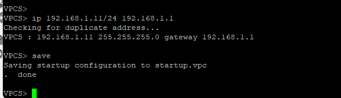

Настройка IP-адреса узла PC1 и сохранение конфигурации

## Настройка PC2 и проверка связи

Узлу `PC2-eegashimova` назначен IP-адрес `192.168.1.12/24`.

Связь между узлами проверена командой `ping`.

[figure not shown]

Настройка PC2 и проверка связи с PC1

# Анализ трафика в Wireshark

## Захват сетевого трафика

На соединении между `PC1-eegashimova` и Ethernet-коммутатором включён захват пакетов.

[figure not shown]

Захват трафика на соединении между PC1 и коммутатором

## Анализ ARP

В Wireshark зафиксированы ARP-сообщения.

Gratuitous ARP используется узлом для объявления собственного IP-адреса и обнаружения возможного конфликта адресов.

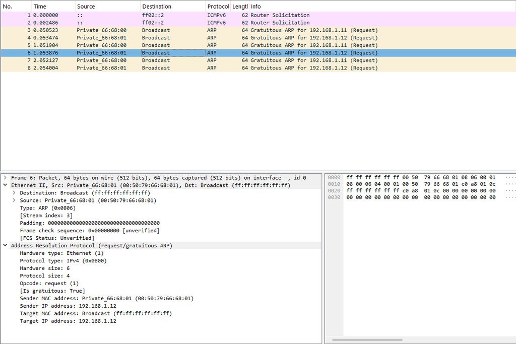

Анализ Gratuitous ARP в Wireshark

## Проверка различных режимов ping

В VPCS выполнена проверка соединения в трёх режимах:

- ICMP;
- UDP;
- TCP.

Во всех случаях удалённый узел успешно отвечает.

[figure not shown]

Выполнение ICMP-, UDP- и TCP-проверки между VPCS

## Анализ ICMP

При стандартной проверке `ping` передаются сообщения `ICMP Echo Request` и `ICMP Echo Reply`.

Наличие ответного пакета подтверждает доступность удалённого узла.

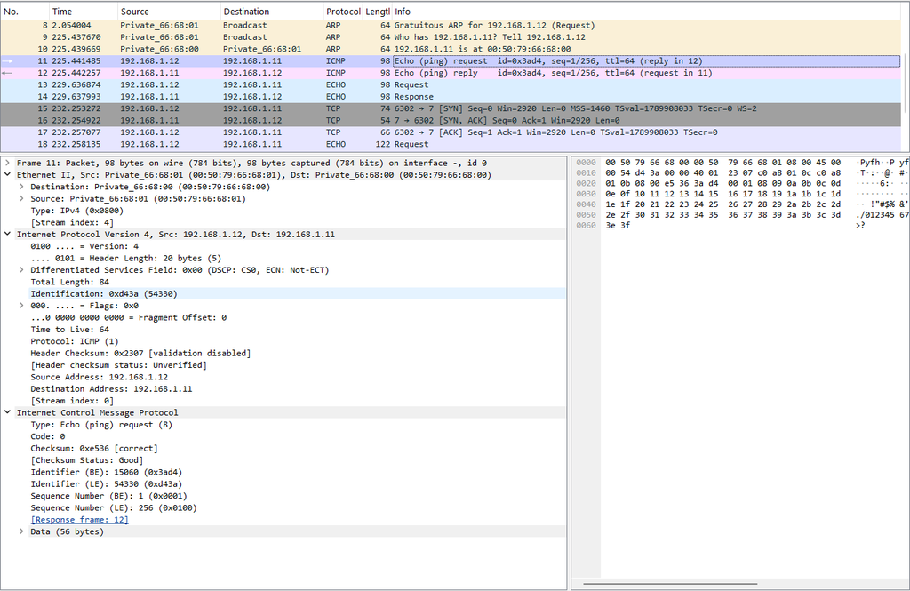

Анализ ICMP Echo Request и Echo Reply в Wireshark

## Анализ UDP

При проверке в UDP-режиме между узлами передаются UDP-дейтаграммы.

UDP не требует предварительного установления соединения между устройствами.

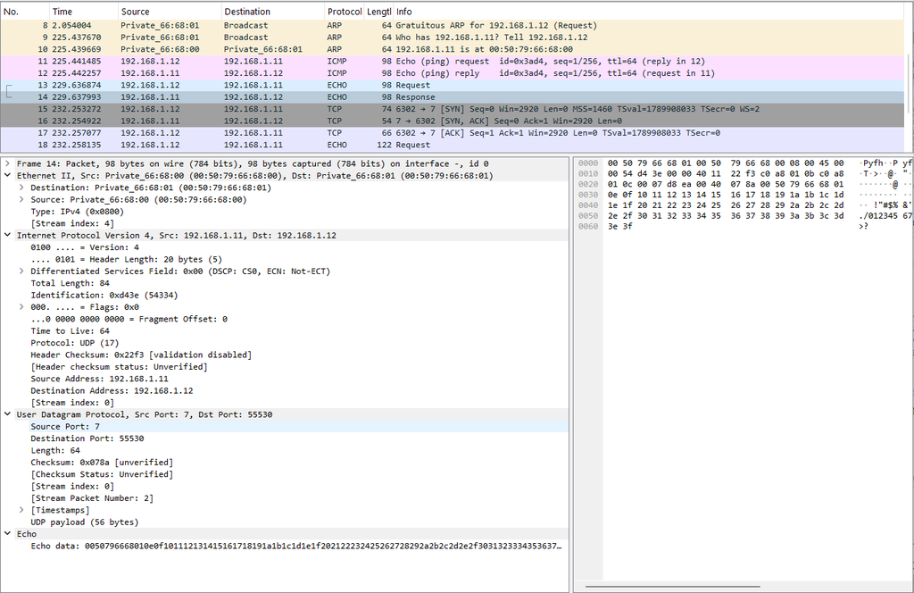

Анализ обмена в UDP-режиме в Wireshark

## Анализ TCP

При проверке в TCP-режиме перед передачей данных выполняется установка соединения:

`SYN` → `SYN, ACK` → `ACK`.

После передачи данных соединение завершается с использованием флагов `FIN` и `ACK`.

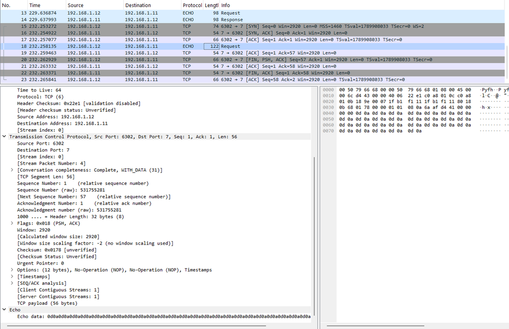

Анализ TCP-режима проверки в Wireshark

# Сеть на базе маршрутизатора FRR

## Топология с FRR

В GNS3 создана сеть, состоящая из VPCS, Ethernet-коммутатора и маршрутизатора FRR.

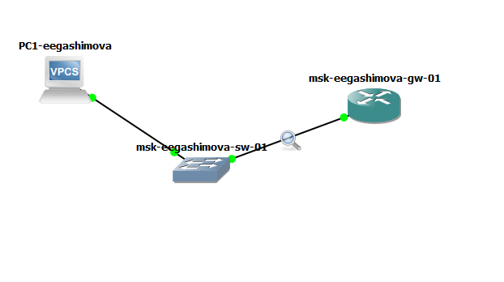

Топология сети с маршрутизатором FRR

## Настройка оконечного устройства

Узлу `PC1-eegashimova` назначен адрес:

`192.168.1.10/24`

В качестве шлюза указан маршрутизатор:

`192.168.1.1`

[figure not shown]

Настройка IP-адреса узла PC1 для сети с FRR

## Настройка маршрутизатора FRR

Маршрутизатору присвоено имя `msk-eegashimova-gw-01`.

Интерфейсу `eth0` назначен адрес `192.168.1.1/24`.

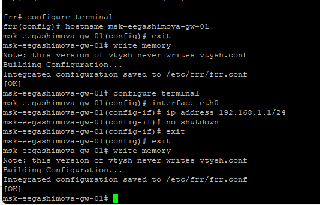

Настройка имени и интерфейса eth0 маршрутизатора FRR

## Проверка конфигурации FRR

Для проверки настроек использованы команды:

`show running-config`

`show interface brief`

Интерфейс `eth0` находится в состоянии `up`.

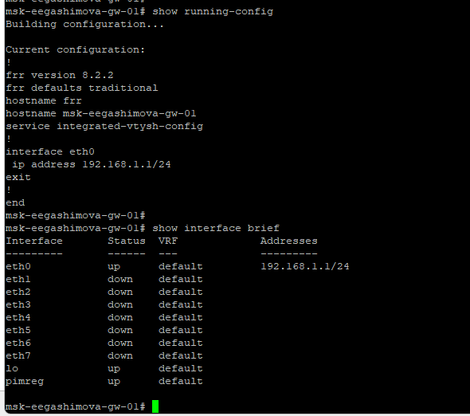

Проверка конфигурации и состояния интерфейсов FRR

## Проверка связи с FRR

С узла `PC1-eegashimova` выполнена команда:

`ping 192.168.1.1`

Получены ответы от маршрутизатора без потери пакетов.

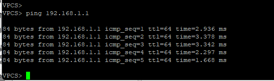

Проверка связи между PC1 и маршрутизатором FRR

## Анализ трафика FRR

Перед передачей ICMP-пакетов выполняется ARP-разрешение IP-адреса маршрутизатора.

После этого между `192.168.1.10` и `192.168.1.1` передаются сообщения `Echo Request` и `Echo Reply`.

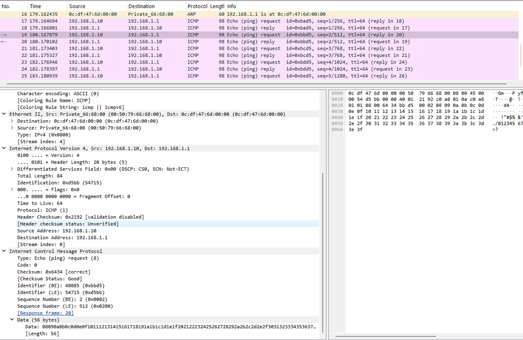

Анализ ARP- и ICMP-трафика при работе с маршрутизатором FRR

# Сеть на базе маршрутизатора VyOS

## Топология с VyOS

Создана сеть, состоящая из VPCS, Ethernet-коммутатора и маршрутизатора VyOS.

[figure not shown]

Топология сети с маршрутизатором VyOS

## Настройка оконечного устройства

Узлу `PC1-eegashimova` назначен адрес `192.168.1.10/24`.

Шлюзом по умолчанию является адрес `192.168.1.1`.

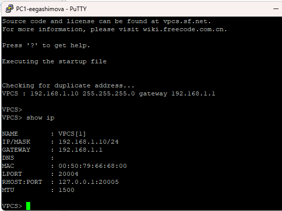

Проверка IP-конфигурации PC1 в сети с VyOS

## Настройка маршрутизатора VyOS

Для интерфейса `eth0` удалено получение IP-адреса по DHCP.

Интерфейсу назначен статический адрес `192.168.1.1/24`.

Конфигурация применена и сохранена.

[figure not shown]

Настройка маршрутизатора VyOS

## Проверка интерфейсов VyOS

Командой `show interfaces` проверено состояние сетевых интерфейсов маршрутизатора.

Интерфейс `eth0` имеет адрес `192.168.1.1/24`.

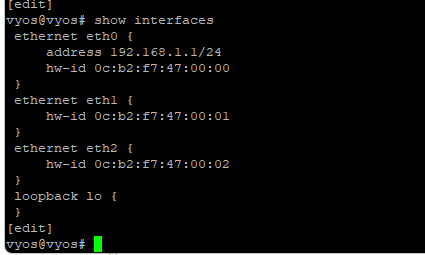

Просмотр интерфейсов маршрутизатора VyOS

## Проверка связи с VyOS

С узла `PC1-eegashimova` выполнена проверка доступности маршрутизатора.

Все ICMP-запросы получили ответы.

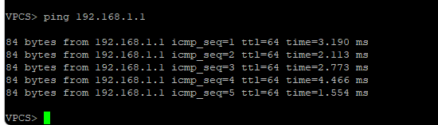

Проверка связи между PC1 и маршрутизатором VyOS

## Анализ трафика VyOS

В Wireshark зафиксирован ARP-обмен между компьютером и маршрутизатором.

После определения MAC-адресов выполняется обмен сообщениями `ICMP Echo Request` и `ICMP Echo Reply`.

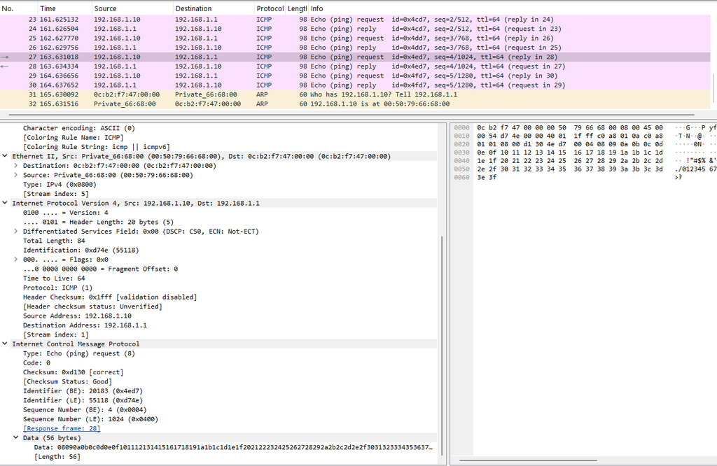

Анализ ARP- и ICMP-трафика при работе с маршрутизатором VyOS

# Результаты работы

## Выполненные действия

В GNS3 построена простая локальная сеть на базе Ethernet-коммутатора и двух VPCS.

Настроена IP-адресация оконечных устройств и проверена связь между ними.

С помощью Wireshark проанализированы протоколы ARP и ICMP, а также работа проверки соединения в UDP- и TCP-режимах.

Построены и настроены сети с маршрутизаторами FRR и VyOS.

## Полученные результаты

Для VPCS настроены адреса сети `192.168.1.0/24`.

Для маршрутизаторов FRR и VyOS настроен адрес `192.168.1.1/24`.

Работоспособность построенных топологий подтверждена успешным выполнением команды `ping`.

В Wireshark зафиксированы ARP-, ICMP-, UDP- и TCP-пакеты.

## Вывод

В результате выполнения лабораторной работы получены практические навыки создания и настройки сетевых топологий в GNS3.

Освоена настройка IP-адресации VPCS, маршрутизаторов FRR и VyOS.

Изучены механизмы работы протокола ARP и передачи ICMP-, UDP- и TCP-пакетов.

Анализ трафика в Wireshark подтвердил корректную работу созданных сетей и настроенных устройств.